```python
# All required IMPORTS!

#!pip uninstall scikit-learn -y
#!pip install scikit-learn


import pandas as pd
import numpy as np
import os
import matplotlib.pyplot as plt
import matplotlib
import seaborn as sns
from io import BytesIO
from zipfile import ZipFile
from time import time
import sklearn
from skimage import io
from skimage.color import rgb2gray
from sklearn.decomposition import PCA
from sklearn.manifold import TSNE
from sklearn.preprocessing import OneHotEncoder, OrdinalEncoder, LabelEncoder
from sklearn.model_selection import train_test_split, cross_val_score
from sklearn.feature_extraction.text import TfidfVectorizer, CountVectorizer
from sklearn.decomposition import NMF, LatentDirichletAllocation
from matplotlib.image import imread
import glob

import warnings


warnings.filterwarnings('ignore')
```

# Cat Faces:

Get the cat-faces dataset from: https://github.com/fferlito/Cat-faces-dataset Load all the images in the first zip file. Use scikit-image (https://scikit-image.org/) to load the images and convert them to grayscale (rgb2gray). Adapt the code from the following website to work with the cat faces: https://scikit-learn.org/stable/auto_examples/decomposition/plot_faces_decomposition.html

```python
!tar -xzvf "/content/dataset-part1.tar.gz" -C "/content/output_folder"     #[run this cell to extract tar.gz files]

#for every new session, upload dataset-part1.tar.gz and create the empty folder output_folder in the correct space in colab in order for this to work
```

[output not shown]

[output cut: 4946 more lines]

[output not shown]

```python
#from google.colab import drive
#drive.mount('/content/drive')
```

```python
path = "/content/output_folder/dataset-part1"

# save all of the file names to a list and
# then loop through this list reading your images (numpy arrays) into a new list

print("\nRetrieving cats images from:")
print(path)

folders = glob.glob(path)
i = 0
cat_col = []

for folder in folders:
    for f in glob.glob(folder+'/*.png'):
        i = i +1
        cat_col.append(f)

print("\nCat images found: " + np.str(i))
```

```
Retrieving cats images from:
/content/output_folder/dataset-part1

Cat images found: 10000
```

# Grayscale image

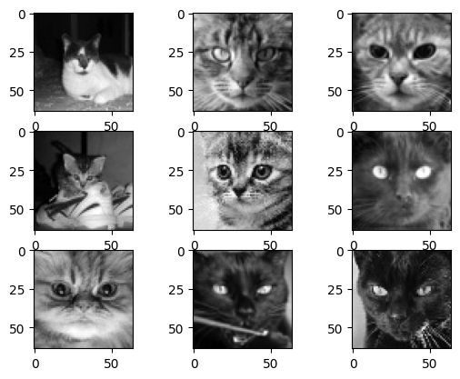

```python
import cv2

fig, ax = plt.subplots(nrows=3, ncols=3)
axes = ax.flatten()


for i in range(9):
    path=cat_col[i]
    img = cv2.imread(path)
    axes[i].imshow(rgb2gray(img), cmap=plt.cm.gray)

plt.show()
```

```python
# Set the array in gray
cat_col_num = []

for i in range(0,10000):
  cat_col_num.append(rgb2gray(imread(cat_col[i])))

print(len(cat_col_num))
```

```
10000
```

```python
cat_col_num = np.array(cat_col_num)
cat_resh = cat_col_num.reshape(cat_col_num.shape[0], cat_col_num.shape[1] * cat_col_num.shape[1])

cat_centered = cat_resh - cat_resh.mean(axis=0)
cat_centered -= cat_centered.mean(axis=1).reshape(cat_col_num.shape[0], -1)
```

[figure not shown]

```python
# Plot similar to the previous plot
fig, ax = plt.subplots(nrows=3, ncols=3)
axes = ax.flatten()

for i in range(9):
    img = cat_centered[i]
    axes[i].imshow(np.reshape(img, (64, 64)), cmap=plt.cm.gray)

plt.show()
```

Center Mean at 0

Next, you will work on selecting the number of components. You may have seen a plot before using the eigenvalues. Recreate this plot for the cat dataset: you can get them from the PCA model object. However, you have another method to select the number of components, now that you can use cross-validation. Look at this example from the scikit-learn documentation to see how to use cross-validation with PCA. Then, using the cat faces dataset, make a plot of reconstruction error for PCA using sklearn. https://scikit-learn.org/stable/auto_examples/decomposition/plot_pca_vs_fa_model_selection.html

```python
cv_scores = []
var_ratio = []
for i in range(0, 21):
    # Apply "full" PCA here:
    pca = PCA(n_components=i, svd_solver="full")
    print('n_components = %d' % i)
    # create cv_scores applying cross_val_score with the data and pca mean value:
    ## You can consider n_jobs=2
    cv_scores.append(np.mean(cross_val_score(pca, cat_centered, n_jobs=2)))
    # Append the explained variance ratio to the var_ratio list
    var_ratio.append(pca.fit(cat_centered).explained_variance_ratio_)
```

```
n_components = 0
n_components = 1
n_components = 2
n_components = 3
n_components = 4
n_components = 5
n_components = 6
n_components = 7
n_components = 8
n_components = 9
n_components = 10
n_components = 11
n_components = 12
n_components = 13
n_components = 14
n_components = 15
n_components = 16
n_components = 17
n_components = 18
n_components = 19
n_components = 20
```

```python
# Add the last component and fit the pca here:
pca = PCA(n_components=21,svd_solver="full")

# Fit the PCA to the data
pca.fit(cat_centered)
```

```
PCA(n_components=21, svd_solver='full')
```

```python
# Form the reconstruction Error here:
rec_error = pd.DataFrame({'n_components': np.arange(21),
                          'reconst error': cv_scores,
                          'explained var ratio': var_ratio})
```

```python
# define a function to extract the last element from a list
def get_last_number(lst):
    return lst[-1]

# apply the function to the 'numbers' column and assign the result to a new column
rec_error['explained_variance'] = rec_error.iloc[1:,]['explained var ratio'].apply(get_last_number)
```

```python
rec_error.head(21)
```

|  | n_components | reconst error | explained var ratio | explained_variance |
| --- | --- | --- | --- | --- |
| 0 | 0 | 762.350377 | [] | NaN |
| 1 | 1 | 1123.753979 | [0.16368744] | 0.163687 |
| 2 | 2 | 1479.866577 | [0.16368744, 0.13504285] | 0.135043 |
| 3 | 3 | 1744.757910 | [0.16368744, 0.13504285, 0.08627736] | 0.086277 |
| 4 | 4 | 1880.144141 | [0.16368744, 0.13504285, 0.08627736, 0.040495787] | 0.040496 |
| 5 | 5 | 2000.712891 | [0.16368744, 0.13504285, 0.08627736, 0.0404957... | 0.034499 |
| 6 | 6 | 2126.003418 | [0.16368744, 0.13504285, 0.08627736, 0.0404957... | 0.032567 |
| 7 | 7 | 2223.979736 | [0.16368744, 0.13504285, 0.08627736, 0.0404957... | 0.024739 |
| 8 | 8 | 2322.511133 | [0.16368744, 0.13504285, 0.08627736, 0.0404957... | 0.023518 |
| 9 | 9 | 2400.702832 | [0.16368744, 0.13504285, 0.08627736, 0.0404957... | 0.018604 |
| 10 | 10 | 2486.715381 | [0.16368744, 0.13504285, 0.08627736, 0.0404957... | 0.018422 |
| 11 | 11 | 2553.970068 | [0.16368744, 0.13504285, 0.08627736, 0.0404957... | 0.014447 |
| 12 | 12 | 2612.181787 | [0.16368744, 0.13504285, 0.08627736, 0.0404957... | 0.012583 |
| 13 | 13 | 2675.324854 | [0.16368744, 0.13504285, 0.08627736, 0.0404957... | 0.012334 |
| 14 | 14 | 2735.040479 | [0.16368744, 0.13504285, 0.08627736, 0.0404957... | 0.011550 |
| 15 | 15 | 2783.367773 | [0.16368744, 0.13504285, 0.08627736, 0.0404957... | 0.009468 |
| 16 | 16 | 2832.248145 | [0.16368744, 0.13504285, 0.08627736, 0.0404957... | 0.009140 |
| 17 | 17 | 2875.548340 | [0.16368744, 0.13504285, 0.08627736, 0.0404957... | 0.008097 |
| 18 | 18 | 2919.866797 | [0.16368744, 0.13504285, 0.08627736, 0.0404957... | 0.007864 |
| 19 | 19 | 2961.180322 | [0.16368744, 0.13504285, 0.08627736, 0.0404957... | 0.007296 |
| 20 | 20 | 2998.108740 | [0.16368744, 0.13504285, 0.08627736, 0.0404957... | 0.006569 |

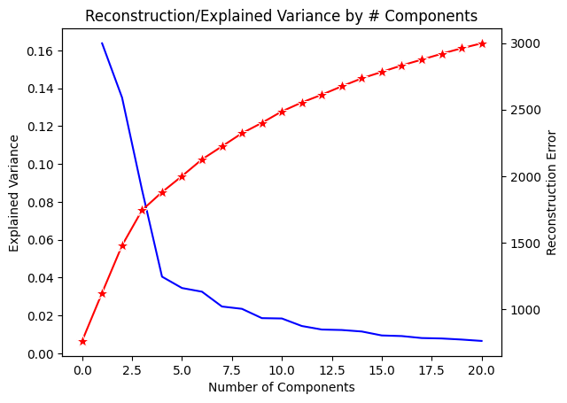

```python
# Plot it here:
fig, ax = plt.subplots()
sns.lineplot(data = rec_error.iloc[1:,], x='n_components', y='explained_variance', color='blue')

# Use twin Axes here:
ax2 = ax.twinx()
sns.lineplot(x=rec_error['n_components'], y=rec_error['reconst error'], ax=ax2, color='red', marker='*', markersize=10)

plt.title('Reconstruction/Explained Variance by # Components')
ax.set_xlabel('Number of Components')
ax.set_ylabel('Explained Variance')
ax2.set_ylabel('Reconstruction Error')
plt.show()
```

# **2 Clothing Reviews with Unsupervised Learning**

Next, you will revisit our clothing reviews dataset. Load the JSON data from modcloth as you did in assignment module 4.

```python
#for every new session, upload modcloth_final_data.json

modcloth = pd.read_json('modcloth_final_data.json', lines=True)
modcloth.head()
```

|  | item_id | waist | size | quality | cup size | hips | bra size | category | bust | height | user_name | length | fit | user_id | shoe size | shoe width | review_summary | review_text |
| --- | --- | --- | --- | --- | --- | --- | --- | --- | --- | --- | --- | --- | --- | --- | --- | --- | --- | --- |
| 0 | 123373 | 29.0 | 7 | 5.0 | d | 38.0 | 34.0 | new | 36 | 5ft 6in | Emily | just right | small | 991571 | NaN | NaN | NaN | NaN |
| 1 | 123373 | 31.0 | 13 | 3.0 | b | 30.0 | 36.0 | new | NaN | 5ft 2in | sydneybraden2001 | just right | small | 587883 | NaN | NaN | NaN | NaN |
| 2 | 123373 | 30.0 | 7 | 2.0 | b | NaN | 32.0 | new | NaN | 5ft 7in | Ugggh | slightly long | small | 395665 | 9.0 | NaN | NaN | NaN |
| 3 | 123373 | NaN | 21 | 5.0 | dd/e | NaN | NaN | new | NaN | NaN | alexmeyer626 | just right | fit | 875643 | NaN | NaN | NaN | NaN |
| 4 | 123373 | NaN | 18 | 5.0 | b | NaN | 36.0 | new | NaN | 5ft 2in | dberrones1 | slightly long | small | 944840 | NaN | NaN | NaN | NaN |

```python
cat_cols = []
for i in modcloth.columns:
  if modcloth[i].dtype.name=='object':
    cat_cols.append(i)
```

```python
cat_df = modcloth[cat_cols]
cat_df.head()
```

|  | cup size | category | bust | height | user_name | length | fit | shoe width | review_summary | review_text |
| --- | --- | --- | --- | --- | --- | --- | --- | --- | --- | --- |
| 0 | d | new | 36 | 5ft 6in | Emily | just right | small | NaN | NaN | NaN |
| 1 | b | new | NaN | 5ft 2in | sydneybraden2001 | just right | small | NaN | NaN | NaN |
| 2 | b | new | NaN | 5ft 7in | Ugggh | slightly long | small | NaN | NaN | NaN |
| 3 | dd/e | new | NaN | NaN | alexmeyer626 | just right | fit | NaN | NaN | NaN |
| 4 | b | new | NaN | 5ft 2in | dberrones1 | slightly long | small | NaN | NaN | NaN |

**Ordinal Encoder**

Use OrdinalEncoder to transform the categorical data to numerical values. Combine the categorical and numerical data into a single data frame.

```python
# Ordinal Encoding on Nominal Values
# Per assignment instructions
encoder = OrdinalEncoder()
cat_encoded = encoder.fit_transform(cat_df)
num_df = pd.DataFrame(cat_encoded, columns=cat_cols)
modcloth_encoded = pd.concat([modcloth.drop(cat_cols, axis=1), num_df], axis=1)

modcloth_encoded.head()
```

|  | item_id | waist | size | quality | hips | bra size | user_id | shoe size | cup size | category | bust | height | user_name | length | fit | shoe width | review_summary | review_text |
| --- | --- | --- | --- | --- | --- | --- | --- | --- | --- | --- | --- | --- | --- | --- | --- | --- | --- | --- |
| 0 | 123373 | 29.0 | 7 | 5.0 | 38.0 | 34.0 | 991571 | NaN | 4.0 | 2.0 | 15.0 | 23.0 | 1347.0 | 0.0 | 2.0 | NaN | NaN | NaN |
| 1 | 123373 | 31.0 | 13 | 3.0 | 30.0 | 36.0 | 587883 | NaN | 2.0 | 2.0 | NaN | 19.0 | 30229.0 | 0.0 | 2.0 | NaN | NaN | NaN |
| 2 | 123373 | 30.0 | 7 | 2.0 | NaN | 32.0 | 395665 | 9.0 | 2.0 | 2.0 | NaN | 24.0 | 4286.0 | 1.0 | 2.0 | NaN | NaN | NaN |
| 3 | 123373 | NaN | 21 | 5.0 | NaN | NaN | 875643 | NaN | 5.0 | 2.0 | NaN | NaN | 5295.0 | 0.0 | 0.0 | NaN | NaN | NaN |
| 4 | 123373 | NaN | 18 | 5.0 | NaN | 36.0 | 944840 | NaN | 2.0 | 2.0 | NaN | 19.0 | 11138.0 | 1.0 | 2.0 | NaN | NaN | NaN |

```python
pd.isna(modcloth_encoded).sum(axis=0)
```

```
item_id               0
waist             79908
size                  0
quality              68
hips              26726
bra size           6018
user_id               0
shoe size         54875
cup size           6255
category              0
bust              70936
height             1107
user_name             0
length               35
fit                   0
shoe width        64183
review_summary     6725
review_text        6725
dtype: int64
```

```python
#@title Default title text
mod_dropped = ['item_id','user_id','user_name','review_summary','review_text','fit']
labels = modcloth_encoded['quality']

# Use concat and then sum funtion here:
X = modcloth_encoded.drop(columns=mod_dropped)
X = X.drop(columns = 'quality')
```

```python
X
```

|  | waist | size | hips | bra size | shoe size | cup size | category | bust | height | length | shoe width |
| --- | --- | --- | --- | --- | --- | --- | --- | --- | --- | --- | --- |
| 0 | 29.0 | 7 | 38.0 | 34.0 | NaN | 4.0 | 2.0 | 15.0 | 23.0 | 0.0 | NaN |
| 1 | 31.0 | 13 | 30.0 | 36.0 | NaN | 2.0 | 2.0 | NaN | 19.0 | 0.0 | NaN |
| 2 | 30.0 | 7 | NaN | 32.0 | 9.0 | 2.0 | 2.0 | NaN | 24.0 | 1.0 | NaN |
| 3 | NaN | 21 | NaN | NaN | NaN | 5.0 | 2.0 | NaN | NaN | 0.0 | NaN |
| 4 | NaN | 18 | NaN | 36.0 | NaN | 2.0 | 2.0 | NaN | 19.0 | 1.0 | NaN |
| ... | ... | ... | ... | ... | ... | ... | ... | ... | ... | ... | ... |
| 82785 | NaN | 8 | NaN | 36.0 | 8.5 | 2.0 | 3.0 | NaN | 25.0 | 0.0 | 0.0 |
| 82786 | NaN | 12 | NaN | 34.0 | NaN | 6.0 | 3.0 | NaN | 22.0 | 1.0 | NaN |
| 82787 | NaN | 12 | 36.0 | 32.0 | NaN | 7.0 | 3.0 | NaN | 21.0 | 0.0 | NaN |
| 82788 | NaN | 12 | NaN | NaN | NaN | NaN | 3.0 | NaN | 20.0 | 0.0 | NaN |
| 82789 | NaN | 4 | 39.0 | 32.0 | NaN | 4.0 | 3.0 | NaN | 27.0 | 0.0 | NaN |

82790 rows × 11 columns

**Statsmodels PCA**

Unfortunately, there is a lot of missing data, which prevents us from directly performing PCA on these data. Instead, you can use the statsmodels package, which has an implementation of PCA that can handle missing data. Install the statsmodels package here: https://www.statsmodels.org/stable/install.html, and use their PCA function:

```
pc = PCA(X, ncomp=2, method='nipals' ,missing='fill-em')
```

Use seaborn’s scatterplot to plot the first two principal components. Check the statsmodels documentation for information on how to access the principal components from the pc object.

You can use scatterplot with hue=labels to color code the plot by label, as below:

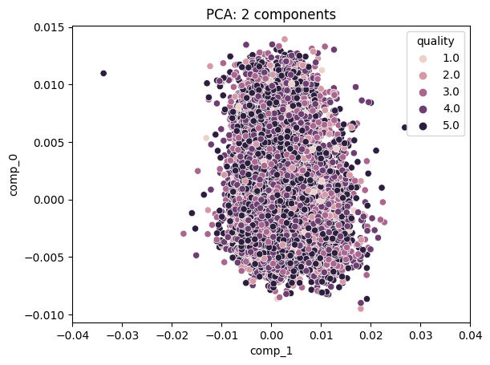

```python
from statsmodels.multivariate.pca import PCA

pc = PCA(X, ncomp=2, method='nipals', missing='fill-em')

# Plot here:
# Extract the first two principal components
pc1 = pc.factors['comp_0']
pc2 = pc.factors['comp_1']

# Create a new dataframe with the principal components
pc_df = pd.DataFrame({'PC1': pc1, 'PC2': pc2})

# Plot the first two principal components using seaborn's scatterplot
p1 = sns.scatterplot(x='PC2', y='PC1', data=pc_df, hue = labels)
p1.set_xlim(-0.04,0.04)
p1.set_xlabel('comp_1')
p1.set_ylabel('comp_0')
p1.set_title('PCA: 2 components')
```

Repeat the above exercise, but now include labels in the features you use to fit the PCA. This time, you can observe label information in the resulting plot.

PCA including label information

```
(-0.02, 0.02)
```

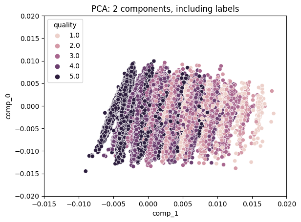

```python
pc2 = PCA(modcloth_encoded.drop(columns=mod_dropped), ncomp=2, method='nipals', missing='fill-em')

# Plot here:
# Extract the first two principal components
pc1 = pc2.factors['comp_0']
pc_2 = pc2.factors['comp_1']

# Create a new dataframe with the principal components
pc_df = pd.DataFrame({'PC1': pc1, 'PC2': pc_2})

# Plot here:
p2 = sns.scatterplot(x='PC2', y='PC1', data=pc_df, hue = labels)
p2.set_xlabel('comp_1')
p2.set_ylabel('comp_0')
p2.set_title('PCA: 2 components, including labels')
p2.set_xlim(-0.015,0.02)
p2.set_ylim(-0.02,0.02)
```

# Unsupervised Learning on Clothing Reviews

Next, you will look for structure in the text data.

Adapt the code in the Latent Dirichlet Allocation example in scikit- learn to work with the text of the clothing reviews: https://scikit-learn.org/stable/auto_examples/applications/plot_topics_extraction_with_nmf_lda.html#sphx-glr-auto-examples-applications-plot-topics-extraction-with-nmf-lda-py. You should have code from assignment module 4 to extract the bag of words features you will need, which you can then pass to the LDA object. Modify the code in this example to fit a model with 10 components (topics) to the reviews. Use the plotting function to visualize the top words in each topic.

```python
# summary of review_text
modcloth['review_text'].describe()
```

```
count        76065
unique       73313
top       Love it!
freq           153
Name: review_text, dtype: object
```

CountVectorizer

```python
# Use the same part of the Assignment 4 here:
# Set the feature numbers 1000
vectorizer = CountVectorizer(
    max_df=0.95, min_df=2, max_features=1000, stop_words="english"
)

#spmat = ...
#feat_names = ...
X_review = modcloth.loc[pd.notna(modcloth['review_text']), 'review_text']
```

```python
# Review the following link and define "plot_top_words":

def plot_top_words(model, feature_names, n_top_words, title):
    fig, axes = plt.subplots(2, 5, figsize=(30, 15), sharex=True)
    axes = axes.flatten()
    for topic_idx, topic in enumerate(model.components_):
        top_features_ind = topic.argsort()[: -n_top_words - 1 : -1]
        top_features = [feature_names[i] for i in top_features_ind]
        weights = topic[top_features_ind]

        ax = axes[topic_idx]
        ax.barh(top_features, weights, height=0.7)
        ax.set_title(f"Topic {topic_idx +1}", fontdict={"fontsize": 30})
        ax.invert_yaxis()
        ax.tick_params(axis="both", which="major", labelsize=20)
        for i in "top right left".split():
            ax.spines[i].set_visible(False)
        fig.suptitle(title, fontsize=40)

    plt.subplots_adjust(top=0.90, bottom=0.05, wspace=0.90, hspace=0.3)
    plt.show()

# https://scikit-learn.org/stable/auto_examples/applications/plot_topics_extraction_with_nmf_lda.html#sphx-glr-auto-examples-applications-plot-topics-extraction-with-nmf-lda-py
```

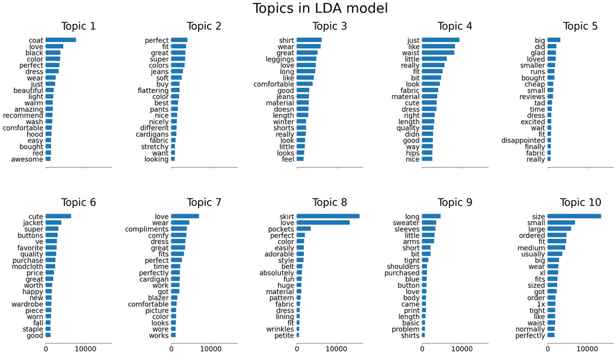

```python
# Use the same link above for ploting the LDA model:

tf = vectorizer.fit_transform(X_review)

lda = LatentDirichletAllocation(
    n_components=10,
    max_iter=5,
    learning_method="online",
    learning_offset=50.0,
    random_state=0,
)
lda.fit(tf)

feat_names = vectorizer.get_feature_names_out()
plot_top_words(lda, feat_names, 20, 'Topics in LDA model')
```

# t-SNE and Manifold Learning

Remove the data points with missing data by using:

`no_missing_data = X.dropna()`

```python
no_missing_data = X.dropna()
no_missing_data
```

|  | waist | size | hips | bra size | shoe size | cup size | category | bust | height | length | shoe width |
| --- | --- | --- | --- | --- | --- | --- | --- | --- | --- | --- | --- |
| 1069 | 30.0 | 8 | 40.0 | 36.0 | 8.5 | 3.0 | 2.0 | 15.0 | 24.0 | 2.0 | 0.0 |
| 1750 | 27.0 | 8 | 34.0 | 34.0 | 8.0 | 7.0 | 2.0 | 18.0 | 7.0 | 0.0 | 2.0 |
| 1751 | 33.0 | 12 | 36.0 | 38.0 | 7.5 | 6.0 | 2.0 | 18.0 | 20.0 | 0.0 | 2.0 |
| 2336 | 49.0 | 32 | 51.0 | 42.0 | 9.5 | 5.0 | 2.0 | 31.0 | 23.0 | 0.0 | 2.0 |
| 2367 | 31.0 | 8 | 41.0 | 34.0 | 8.5 | 3.0 | 2.0 | 15.0 | 23.0 | 0.0 | 0.0 |
| ... | ... | ... | ... | ... | ... | ... | ... | ... | ... | ... | ... |
| 80851 | 31.0 | 15 | 39.0 | 36.0 | 8.0 | 6.0 | 4.0 | 19.0 | 23.0 | 0.0 | 2.0 |
| 80932 | 36.0 | 15 | 42.0 | 38.0 | 6.5 | 4.0 | 3.0 | 24.0 | 20.0 | 0.0 | 2.0 |
| 80942 | 30.0 | 8 | 40.0 | 36.0 | 8.0 | 3.0 | 3.0 | 14.0 | 21.0 | 0.0 | 2.0 |
| 82654 | 30.0 | 20 | 39.0 | 42.0 | 7.5 | 2.0 | 3.0 | 11.0 | 21.0 | 0.0 | 2.0 |
| 82720 | 38.0 | 26 | 50.0 | 38.0 | 10.5 | 3.0 | 3.0 | 23.0 | 27.0 | 0.0 | 2.0 |

557 rows × 11 columns

```python
# Use 2 components, 40 for perplexity, 5000 iteration, 10 for the Learning rate, 2 for number of jobs and 42 for random_state.
# Fit transform the no missing data
tsne = TSNE(n_components=2,perplexity=40,n_iter=5000,learning_rate=10, n_jobs=2,random_state=42)
tsne_embd = tsne.fit_transform(no_missing_data)
```

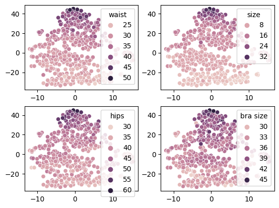

```python
# Plot here:
#sns.scatterplot( data=no_missing_data)


plt.subplot(2,2,1)
sns.scatterplot(x=tsne_embd[:,1],y=tsne_embd[:,0], hue='waist', data=no_missing_data)

plt.subplot(2,2,2)
sns.scatterplot(x=tsne_embd[:,1],y=tsne_embd[:,0], hue='size', data=no_missing_data)

plt.subplot(2,2,3)
sns.scatterplot(x=tsne_embd[:,1],y=tsne_embd[:,0], hue='hips', data=no_missing_data)

plt.subplot(2,2,4)
sns.scatterplot(x=tsne_embd[:,1],y=tsne_embd[:,0], hue='bra size', data=no_missing_data)
```

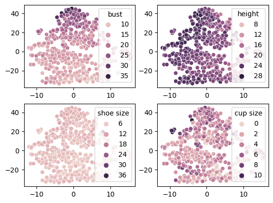

```python
plt.subplot(2,2,1)
sns.scatterplot(x=tsne_embd[:,1],y=tsne_embd[:,0], hue='bust', data=no_missing_data)

plt.subplot(2,2,2)
sns.scatterplot(x=tsne_embd[:,1],y=tsne_embd[:,0], hue='height', data=no_missing_data)

plt.subplot(2,2,3)
sns.scatterplot(x=tsne_embd[:,1],y=tsne_embd[:,0], hue='shoe size', data=no_missing_data)

plt.subplot(2,2,4)
sns.scatterplot(x=tsne_embd[:,1],y=tsne_embd[:,0], hue='cup size', data=no_missing_data)



#scprep.plot.scatter2d(data_tsne, c=metadata_subsample['CELLTYPE'],
 #                     figsize=(8,4), legend_anchor=(1,1),
  #                    ticks=False, label_prefix='t-SNE')
```

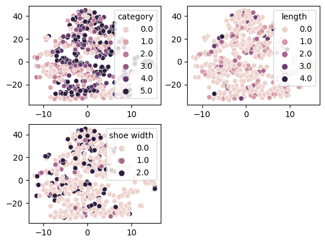

```python
plt.subplot(2,2,1)
sns.scatterplot(x=tsne_embd[:,1],y=tsne_embd[:,0], hue='category', data=no_missing_data)

plt.subplot(2,2,2)
sns.scatterplot(x=tsne_embd[:,1],y=tsne_embd[:,0], hue='length', data=no_missing_data)

plt.subplot(2,2,3)
sns.scatterplot(x=tsne_embd[:,1],y=tsne_embd[:,0], hue='shoe width', data=no_missing_data)
```